# Objective 5: Causal Mediation

Standalone analytical report

Published

May 25, 2026

## 1 Report Purpose

This standalone analytical report records the current Objective 5 causal mediation evidence. It is not a manuscript. Its purpose is to keep the formal mediation estimand, imputation status, total-effect results, mediator-block decompositions, and mediator-specific signals aligned with the current release bundle.

This report uses the 25 May 2026 causal-mediation release bundle. It should be used to check whether the shorter Objective 5 website page is current.

## 2 Source Files

|  | Source file | Modified |
| --- | --- | --- |
| results/causal_mediation/tables/strict_joint_history_pipeline_manifest.csv | results/causal_mediation/tables/strict_joint_history_pipeline_manifest.csv | 2026-05-25 14:35:40 SAST |
| results/causal_mediation/tables/strict_joint_history_mediation_run_manifest.csv | results/causal_mediation/tables/strict_joint_history_mediation_run_manifest.csv | 2026-05-25 14:35:40 SAST |
| results/causal_mediation/tables/strict_joint_history_input_coverage_summary.csv | results/causal_mediation/tables/strict_joint_history_input_coverage_summary.csv | 2026-05-25 14:35:40 SAST |
| results/causal_mediation/tables/strict_joint_history_input_staging_summary.csv | results/causal_mediation/tables/strict_joint_history_input_staging_summary.csv | 2026-05-25 14:35:40 SAST |
| results/causal_mediation/tables/strict_joint_history_imputation_run_manifest.csv | results/causal_mediation/tables/strict_joint_history_imputation_run_manifest.csv | 2026-05-25 14:35:40 SAST |
| results/causal_mediation/tables/strict_joint_history_imputation_manifest.csv | results/causal_mediation/tables/strict_joint_history_imputation_manifest.csv | 2026-05-25 14:35:40 SAST |
| results/causal_mediation/tables/strict_joint_history_total_effect_results.csv | results/causal_mediation/tables/strict_joint_history_total_effect_results.csv | 2026-05-25 14:35:40 SAST |
| results/causal_mediation/tables/strict_joint_history_joint_mediator_results.csv | results/causal_mediation/tables/strict_joint_history_joint_mediator_results.csv | 2026-05-25 14:35:40 SAST |
| results/causal_mediation/tables/strict_joint_history_single_mediator_results.csv | results/causal_mediation/tables/strict_joint_history_single_mediator_results.csv | 2026-05-25 14:35:40 SAST |
| results/causal_mediation/tables/strict_joint_history_fixed_context_indirect_comparison.csv | results/causal_mediation/tables/strict_joint_history_fixed_context_indirect_comparison.csv | 2026-05-25 14:35:40 SAST |
| results/causal_mediation/figures/working_causal_mediation_dag.svg | results/causal_mediation/figures/working_causal_mediation_dag.svg | 2026-05-25 14:35:40 SAST |
| results/causal_mediation/figures/cross_branch_mediation_summary.png | results/causal_mediation/figures/cross_branch_mediation_summary.png | 2026-05-25 14:35:40 SAST |

## 3 SAP Alignment

Objective 5 moves from pathway screening to formal causal mediation. The primary exposure surface is the strict joint maternal-absence plus household socioeconomic status trajectory branch requiring at least three complete childhood occasions. The primary mediator block is food insecurity, violence exposure, and ever having had sexual intercourse.

The analysis estimates total effects, direct effects, combined-pathway indirect effects, and mediator-specific indirect effects on the risk-difference scale. The results are interpreted as observational, model-based mediation evidence under measured-adjustment assumptions.

## 4 Pipeline And Imputation Status

| Run timestamp | Imputations | Seed | Simulation draws | Block simulation draws | Expanded block draws |
| --- | --- | --- | --- | --- | --- |
| 2026-05-04 12:29:05 SAST | 20 | 20,260,414 | 300 | 120 | 0 |

| Run timestamp | Branch | Transition subjects | Transition pseudo rows | Simulation draws | Block simulation draws | Posterior weight floor | Total-effect contrasts | Interval method |
| --- | --- | --- | --- | --- | --- | --- | --- | --- |
| 2026-05-04 12:29:05 SAST | strict | 1,381 | 9,347 | 300 | 120 | 1e-10 | 10 | Rubin pooled over 20 imputations; within-imputation intervals from cluster-robust coefficient simulation. |

| Metric | N | Note |
| --- | --- | --- |
| subject_level_rows | 6,207 | All locally staged subject-level rows. |
| strict_0_5_window_subjects | 1,467 | Subjects with early-childhood strict joint maternal absence and household socioeconomic status saved trajectory output. |
| strict_6_12_window_subjects | 3,478 | Subjects with middle-late-childhood strict joint maternal absence and household socioeconomic status saved trajectory output. |
| subject_level_overlap_0_5 | 1,467 | Subject-level rows overlapping the early-childhood strict joint maternal absence and household socioeconomic status saved trajectory output. |
| subject_level_overlap_6_12 | 3,478 | Subject-level rows overlapping the middle-late-childhood strict joint maternal absence and household socioeconomic status saved trajectory output. |
| base_complete_subjects | 5,867 | Subjects complete on SEX, core base mediators, and depressive symptoms. |
| base_complete_overlap_0_5 | 1,449 | Base-complete subject-level rows overlapping the early-childhood strict joint maternal absence and household socioeconomic status saved trajectory output. |
| base_complete_overlap_6_12 | 3,382 | Base-complete subject-level rows overlapping the middle-late-childhood strict joint maternal absence and household socioeconomic status saved trajectory output. |
| strict_transition_overlap_subjects | 1,381 | Subjects with overlapping strict joint maternal absence and household socioeconomic status class uncertainty in both windows. |
| base_complete_transition_overlap_subjects | 1,365 | Base-complete subject-level rows overlapping the strict joint maternal absence and household socioeconomic status transition bundle. |

| Content | Window | N subjects | Detail |
| --- | --- | --- | --- |
| subject_level_analysis_table | - | 6,207 | Base-complete subjects = 5867 |
| selected_strict_lcga_saved trajectory output | 0-5 years | 1,467 | Strict K = 5; source = lcga_results_time_0_5.rds |
| posterior_long | 0-5 years | 1,467 | Posterior rows = 7335 |
| class_key | 0-5 years | 5 | Latent classes = Class 1, Class 2, Class 3, Class 4, Class 5 |
| selected_strict_lcga_saved trajectory output | 6-12 years | 3,478 | Strict K = 8; source = lcga_results_time_6_12.rds |
| posterior_long | 6-12 years | 3,478 | Posterior rows = 27824 |
| class_key | 6-12 years | 8 | Latent classes = Class 1, Class 2, Class 3, Class 4, Class 5, Class 6, Class 7, Class 8 |
| saved_probs | 0-5 years + 6-12 years | 1,381 | Overlap subjects = 1381; joint classes = 40 |
| joint_map | - | 40 | Joint class labels = 40 |
| mplus_transition | - | 40 | Posterior-weighted conditional transition probabilities |
| summary | - | 8 | Joint row totals range = 0.998 to 1.002 |

| Run timestamp | Overlap subjects | Imputations | Maximum iterations | Seed |
| --- | --- | --- | --- | --- |
| 2026-05-04 11:01:48 SAST | 1,381 | 20 | 20 | 20,260,414 |

| Imputation | N subjects | Missing values after imputation | Residual fills |
| --- | --- | --- | --- |
| 1 | 1,381 | 0 | 8 |
| 2 | 1,381 | 0 | 8 |
| 3 | 1,381 | 0 | 8 |
| 4 | 1,381 | 0 | 8 |
| 5 | 1,381 | 0 | 8 |
| 6 | 1,381 | 0 | 8 |
| 7 | 1,381 | 0 | 8 |
| 8 | 1,381 | 0 | 8 |
| 9 | 1,381 | 0 | 8 |
| 10 | 1,381 | 0 | 8 |
| 11 | 1,381 | 0 | 8 |
| 12 | 1,381 | 0 | 8 |
| 13 | 1,381 | 0 | 8 |
| 14 | 1,381 | 0 | 8 |
| 15 | 1,381 | 0 | 8 |
| 16 | 1,381 | 0 | 8 |
| 17 | 1,381 | 0 | 8 |
| 18 | 1,381 | 0 | 8 |
| 19 | 1,381 | 0 | 8 |
| 20 | 1,381 | 0 | 8 |

| Variable | Missing N | Missing share |
| --- | --- | --- |
| MAGE | 173 | 12.5% |
| MEDU | 222 | 16.1% |
| MHIV | 369 | 26.7% |
| MPTS | 191 | 13.8% |
| MMIG | 173 | 12.5% |

## 5 Causal Structure

[figure not shown]

## 6 Model Diagnostics

| Model type | Adjustment set | Window | Mediator | N subjects | Pseudo rows | Converged all imputations | Warnings |
| --- | --- | --- | --- | --- | --- | --- | --- |
| Mediator model | base | 0-5 years | Alcohol use | 1,381 | 9,347 | Yes | - |
| Mediator-adjusted outcome model | base | 0-5 years | Alcohol use | 1,381 | 9,347 | Yes | - |
| Joint-block mediator-adjusted outcome model | base | 0-5 years | Base pathway block | 1,365 | 9,238 | Yes | - |
| Joint-block sequential mediator model | base | 0-5 years | Base pathway block: Ever had sexual intercourse | 1,365 | 9,238 | Yes | - |
| Joint-block sequential mediator model | base | 0-5 years | Base pathway block: Food insecurity | 1,365 | 9,238 | Yes | - |
| Joint-block sequential mediator model | base | 0-5 years | Base pathway block: Violence exposure | 1,365 | 9,238 | Yes | - |
| Mediator model | base | 0-5 years | Ever had sexual intercourse | 1,365 | 9,238 | Yes | - |
| Mediator-adjusted outcome model | base | 0-5 years | Ever had sexual intercourse | 1,365 | 9,238 | Yes | - |
| Joint-block mediator-adjusted outcome model | base | 0-5 years | Expanded pathway block | 1,365 | 9,238 | Yes | - |
| Joint-block mediator-adjusted outcome model | base | 0-5 years | Expanded pathway block | 1,365 | 9,238 | Yes | - |
| Joint-block sequential mediator model | base | 0-5 years | Expanded pathway block: Alcohol use | 1,365 | 9,238 | Yes | - |
| Joint-block sequential mediator model | base | 0-5 years | Expanded pathway block: Ever had sexual intercourse | 1,365 | 9,238 | Yes | - |
| Joint-block sequential mediator model | base | 0-5 years | Expanded pathway block: Food insecurity | 1,365 | 9,238 | Yes | - |
| Joint-block sequential mediator model | base | 0-5 years | Expanded pathway block: Lack of government grant receipt | 1,365 | 9,238 | Yes | - |
| Joint-block sequential mediator model | base | 0-5 years | Expanded pathway block: Lack of government grant receipt | 1,365 | 9,238 | Yes | - |
| Joint-block sequential mediator model | base | 0-5 years | Expanded pathway block: Low social support | 1,365 | 9,238 | Yes | - |
| Joint-block sequential mediator model | base | 0-5 years | Expanded pathway block: Low social support | 1,365 | 9,238 | Yes | - |
| Joint-block sequential mediator model | base | 0-5 years | Expanded pathway block: School disengagement | 1,365 | 9,238 | Yes | - |
| Joint-block sequential mediator model | base | 0-5 years | Expanded pathway block: School disengagement | 1,365 | 9,238 | Yes | - |
| Joint-block sequential mediator model | base | 0-5 years | Expanded pathway block: Violence exposure | 1,365 | 9,238 | Yes | - |
| Mediator model | base | 0-5 years | Food insecurity | 1,381 | 9,347 | Yes | - |
| Mediator-adjusted outcome model | base | 0-5 years | Food insecurity | 1,381 | 9,347 | Yes | - |
| Mediator model | base | 0-5 years | Lack of government grant receipt | 1,381 | 9,347 | Yes | - |
| Mediator-adjusted outcome model | base | 0-5 years | Lack of government grant receipt | 1,381 | 9,347 | Yes | - |
| Mediator model | base | 0-5 years | Low social support | 1,381 | 9,347 | Yes | - |
| Mediator-adjusted outcome model | base | 0-5 years | Low social support | 1,381 | 9,347 | Yes | - |
| Mediator model | base | 0-5 years | School disengagement | 1,381 | 9,347 | Yes | - |
| Mediator-adjusted outcome model | base | 0-5 years | School disengagement | 1,381 | 9,347 | Yes | - |
| Mediator model | base | 0-5 years | Violence exposure | 1,381 | 9,347 | Yes | - |
| Mediator-adjusted outcome model | base | 0-5 years | Violence exposure | 1,381 | 9,347 | Yes | - |

[output cut: 120 more lines]

## 7 Total Effect Results

| Window | Contrast | N | Reference risk | Comparator risk | Risk difference (95% CI) | Interpretation |
| --- | --- | --- | --- | --- | --- | --- |
| 0-5 years | High Maternal Absence, Low SES vs Low Maternal Absence, Improving SES | 1,381 | 3.0% | 7.1% | 0.042 (-0.014, 0.098) | positive; interval includes 0 |
| 0-5 years | Low Maternal Absence, Low SES vs Low Maternal Absence, Improving SES | 1,381 | 3.0% | 2.8% | -0.002 (-0.023, 0.019) | negative; interval includes 0 |
| 0-5 years | Rising Maternal Absence, Improving SES vs Low Maternal Absence, Improving SES | 1,381 | 3.0% | 2.1% | -0.009 (-0.049, 0.032) | negative; interval includes 0 |
| 0-5 years | Rising Maternal Absence, Low SES vs Low Maternal Absence, Improving SES | 1,381 | 3.0% | 2.9% | -0.001 (-0.031, 0.030) | negative; interval includes 0 |
| 6-12 years | Decreasing Maternal Absence, Low SES vs Low Maternal Absence, Higher SES | 1,381 | 1.8% | 4.0% | 0.022 (-0.026, 0.070) | positive; interval includes 0 |
| 6-12 years | High Maternal Absence, Improving SES vs Low Maternal Absence, Higher SES | 1,381 | 1.8% | 4.3% | 0.025 (-0.011, 0.061) | positive; interval includes 0 |
| 6-12 years | High Maternal Absence, Low SES vs Low Maternal Absence, Higher SES | 1,381 | 1.8% | 8.4% | 0.066 (0.005, 0.127) | positive; interval excludes 0 |
| 6-12 years | Low Maternal Absence, Improving SES vs Low Maternal Absence, Higher SES | 1,381 | 1.8% | 2.4% | 0.006 (-0.014, 0.027) | positive; interval includes 0 |
| 6-12 years | Low Maternal Absence, Low SES vs Low Maternal Absence, Higher SES | 1,381 | 1.8% | 2.0% | 0.002 (-0.026, 0.030) | positive; interval includes 0 |
| 6-12 years | Rising Maternal Absence, Improving SES vs Low Maternal Absence, Higher SES | 1,381 | 1.8% | 5.7% | 0.039 (-0.014, 0.092) | positive; interval includes 0 |

| Adjustment set | Tier | Window | Contrast | N | Reference risk | Comparator risk | Risk difference (95% CI) | Interpretation |
| --- | --- | --- | --- | --- | --- | --- | --- | --- |
| Base causal mediation estimand with imputed maternal baseline | Primary | 0-5 years | High Maternal Absence, Low SES vs Low Maternal Absence, Improving SES | 1,381 | 3.0% | 7.1% | 0.042 (-0.014, 0.098) | positive; interval includes 0 |
| Base causal mediation estimand with imputed maternal baseline | Primary | 0-5 years | Low Maternal Absence, Low SES vs Low Maternal Absence, Improving SES | 1,381 | 3.0% | 2.8% | -0.002 (-0.023, 0.019) | negative; interval includes 0 |
| Base causal mediation estimand with imputed maternal baseline | Primary | 0-5 years | Rising Maternal Absence, Improving SES vs Low Maternal Absence, Improving SES | 1,381 | 3.0% | 2.1% | -0.009 (-0.049, 0.032) | negative; interval includes 0 |
| Base causal mediation estimand with imputed maternal baseline | Primary | 0-5 years | Rising Maternal Absence, Low SES vs Low Maternal Absence, Improving SES | 1,381 | 3.0% | 2.9% | -0.001 (-0.031, 0.030) | negative; interval includes 0 |
| Base causal mediation estimand with imputed maternal baseline | Primary | 6-12 years | Decreasing Maternal Absence, Low SES vs Low Maternal Absence, Higher SES | 1,381 | 1.8% | 4.0% | 0.022 (-0.026, 0.070) | positive; interval includes 0 |
| Base causal mediation estimand with imputed maternal baseline | Primary | 6-12 years | High Maternal Absence, Improving SES vs Low Maternal Absence, Higher SES | 1,381 | 1.8% | 4.3% | 0.025 (-0.011, 0.061) | positive; interval includes 0 |
| Base causal mediation estimand with imputed maternal baseline | Primary | 6-12 years | High Maternal Absence, Low SES vs Low Maternal Absence, Higher SES | 1,381 | 1.8% | 8.4% | 0.066 (0.005, 0.127) | positive; interval excludes 0 |
| Base causal mediation estimand with imputed maternal baseline | Primary | 6-12 years | Low Maternal Absence, Improving SES vs Low Maternal Absence, Higher SES | 1,381 | 1.8% | 2.4% | 0.006 (-0.014, 0.027) | positive; interval includes 0 |
| Base causal mediation estimand with imputed maternal baseline | Primary | 6-12 years | Low Maternal Absence, Low SES vs Low Maternal Absence, Higher SES | 1,381 | 1.8% | 2.0% | 0.002 (-0.026, 0.030) | positive; interval includes 0 |
| Base causal mediation estimand with imputed maternal baseline | Primary | 6-12 years | Rising Maternal Absence, Improving SES vs Low Maternal Absence, Higher SES | 1,381 | 1.8% | 5.7% | 0.039 (-0.014, 0.092) | positive; interval includes 0 |
| Fixed-context-adjusted decomposition with imputed maternal baseline | Primary | 0-5 years | High Maternal Absence, Low SES vs Low Maternal Absence, Improving SES | 1,380 | 3.0% | 6.7% | 0.037 (-0.017, 0.092) | positive; interval includes 0 |
| Fixed-context-adjusted decomposition with imputed maternal baseline | Primary | 0-5 years | Low Maternal Absence, Low SES vs Low Maternal Absence, Improving SES | 1,380 | 3.0% | 2.8% | -0.002 (-0.023, 0.018) | negative; interval includes 0 |
| Fixed-context-adjusted decomposition with imputed maternal baseline | Primary | 0-5 years | Rising Maternal Absence, Improving SES vs Low Maternal Absence, Improving SES | 1,380 | 3.0% | 2.3% | -0.007 (-0.048, 0.035) | negative; interval includes 0 |
| Fixed-context-adjusted decomposition with imputed maternal baseline | Primary | 0-5 years | Rising Maternal Absence, Low SES vs Low Maternal Absence, Improving SES | 1,380 | 3.0% | 2.8% | -0.002 (-0.031, 0.028) | negative; interval includes 0 |
| Fixed-context-adjusted decomposition with imputed maternal baseline | Primary | 6-12 years | Decreasing Maternal Absence, Low SES vs Low Maternal Absence, Higher SES | 1,380 | 1.8% | 3.5% | 0.017 (-0.026, 0.061) | positive; interval includes 0 |
| Fixed-context-adjusted decomposition with imputed maternal baseline | Primary | 6-12 years | High Maternal Absence, Improving SES vs Low Maternal Absence, Higher SES | 1,380 | 1.8% | 4.1% | 0.023 (-0.013, 0.058) | positive; interval includes 0 |
| Fixed-context-adjusted decomposition with imputed maternal baseline | Primary | 6-12 years | High Maternal Absence, Low SES vs Low Maternal Absence, Higher SES | 1,380 | 1.8% | 8.6% | 0.068 (0.003, 0.134) | positive; interval excludes 0 |
| Fixed-context-adjusted decomposition with imputed maternal baseline | Primary | 6-12 years | Low Maternal Absence, Improving SES vs Low Maternal Absence, Higher SES | 1,380 | 1.8% | 2.4% | 0.006 (-0.016, 0.027) | positive; interval includes 0 |
| Fixed-context-adjusted decomposition with imputed maternal baseline | Primary | 6-12 years | Low Maternal Absence, Low SES vs Low Maternal Absence, Higher SES | 1,380 | 1.8% | 2.2% | 0.004 (-0.028, 0.036) | positive; interval includes 0 |
| Fixed-context-adjusted decomposition with imputed maternal baseline | Primary | 6-12 years | Rising Maternal Absence, Improving SES vs Low Maternal Absence, Higher SES | 1,380 | 1.8% | 6.0% | 0.042 (-0.011, 0.095) | positive; interval includes 0 |

## 8 Mediation Decomposition

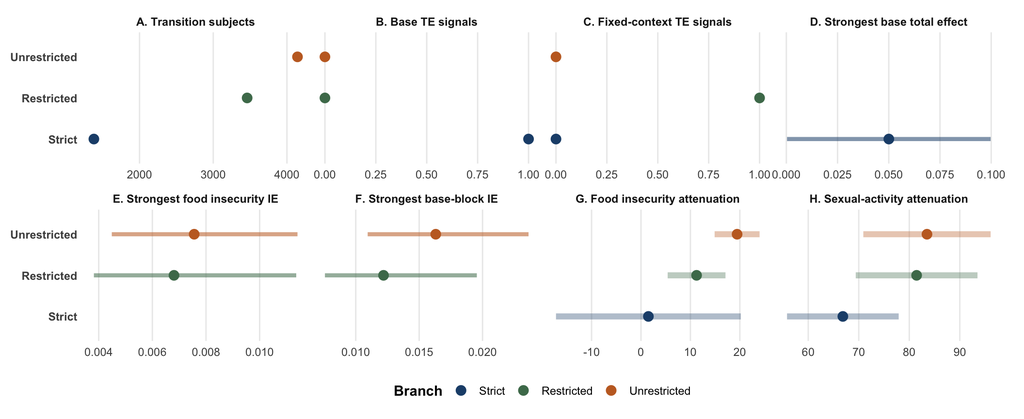

| Window | Contrast | Mediator block | Effect | Risk difference (95% CI) | Percent mediated | Interpretation |
| --- | --- | --- | --- | --- | --- | --- |
| 0-5 years | High Maternal Absence, Low SES vs Low Maternal Absence, Improving SES | Base pathway block | Block direct effect | 0.025 (-0.023, 0.073) | - | positive; interval includes 0 |
| 0-5 years | High Maternal Absence, Low SES vs Low Maternal Absence, Improving SES | Base pathway block | Total effect | 0.038 (-0.017, 0.093) | - | positive; interval includes 0 |
| 0-5 years | High Maternal Absence, Low SES vs Low Maternal Absence, Improving SES | Base pathway block | Total indirect effect | 0.013 (-0.003, 0.028) | 33.3% | positive; interval includes 0 |
| 0-5 years | High Maternal Absence, Low SES vs Low Maternal Absence, Improving SES | Expanded pathway block | Block direct effect | 0.026 | - | positive; interval unavailable |
| 0-5 years | High Maternal Absence, Low SES vs Low Maternal Absence, Improving SES | Expanded pathway block | Total effect | 0.037 | - | positive; interval unavailable |
| 0-5 years | High Maternal Absence, Low SES vs Low Maternal Absence, Improving SES | Expanded pathway block | Total indirect effect | 0.011 | 30.1% | positive; interval unavailable |
| 6-12 years | High Maternal Absence, Low SES vs Low Maternal Absence, Higher SES | Base pathway block | Block direct effect | 0.043 (-0.008, 0.095) | - | positive; interval includes 0 |
| 6-12 years | High Maternal Absence, Low SES vs Low Maternal Absence, Higher SES | Base pathway block | Total effect | 0.064 (0.001, 0.127) | - | positive; interval excludes 0 |
| 6-12 years | High Maternal Absence, Low SES vs Low Maternal Absence, Higher SES | Base pathway block | Total indirect effect | 0.021 (-0.000, 0.042) | 32.4% | positive; interval includes 0 |
| 6-12 years | High Maternal Absence, Low SES vs Low Maternal Absence, Higher SES | Expanded pathway block | Block direct effect | 0.046 | - | positive; interval unavailable |
| 6-12 years | High Maternal Absence, Low SES vs Low Maternal Absence, Higher SES | Expanded pathway block | Total effect | 0.067 | - | positive; interval unavailable |
| 6-12 years | High Maternal Absence, Low SES vs Low Maternal Absence, Higher SES | Expanded pathway block | Total indirect effect | 0.021 | 31.7% | positive; interval unavailable |

| Adjustment set | Tier | Window | Contrast | Mediator block | Effect | N | Risk difference (95% CI) | Percent mediated | Interpretation |
| --- | --- | --- | --- | --- | --- | --- | --- | --- | --- |
| Base causal mediation estimand with imputed maternal baseline | Primary | 0-5 years | High Maternal Absence, Low SES vs Low Maternal Absence, Improving SES | Base pathway block | Block direct effect | 1,365 | 0.025 (-0.023, 0.073) | - | positive; interval includes 0 |
| Base causal mediation estimand with imputed maternal baseline | Primary | 0-5 years | High Maternal Absence, Low SES vs Low Maternal Absence, Improving SES | Base pathway block | Total effect | 1,365 | 0.038 (-0.017, 0.093) | - | positive; interval includes 0 |
| Base causal mediation estimand with imputed maternal baseline | Primary | 0-5 years | High Maternal Absence, Low SES vs Low Maternal Absence, Improving SES | Base pathway block | Total indirect effect | 1,365 | 0.013 (-0.003, 0.028) | 33.3% | positive; interval includes 0 |
| Base causal mediation estimand with imputed maternal baseline | Primary | 0-5 years | High Maternal Absence, Low SES vs Low Maternal Absence, Improving SES | Expanded pathway block | Block direct effect | 1,365 | 0.026 | - | positive; interval unavailable |
| Base causal mediation estimand with imputed maternal baseline | Primary | 0-5 years | High Maternal Absence, Low SES vs Low Maternal Absence, Improving SES | Expanded pathway block | Total effect | 1,365 | 0.037 | - | positive; interval unavailable |
| Base causal mediation estimand with imputed maternal baseline | Primary | 0-5 years | High Maternal Absence, Low SES vs Low Maternal Absence, Improving SES | Expanded pathway block | Total indirect effect | 1,365 | 0.011 | 30.1% | positive; interval unavailable |
| Base causal mediation estimand with imputed maternal baseline | Primary | 0-5 years | Low Maternal Absence, Low SES vs Low Maternal Absence, Improving SES | Base pathway block | Block direct effect | 1,365 | -0.004 (-0.024, 0.016) | - | negative; interval includes 0 |
| Base causal mediation estimand with imputed maternal baseline | Primary | 0-5 years | Low Maternal Absence, Low SES vs Low Maternal Absence, Improving SES | Base pathway block | Total effect | 1,365 | -0.002 (-0.023, 0.019) | - | negative; interval includes 0 |
| Base causal mediation estimand with imputed maternal baseline | Primary | 0-5 years | Low Maternal Absence, Low SES vs Low Maternal Absence, Improving SES | Base pathway block | Total indirect effect | 1,365 | 0.002 (-0.001, 0.006) | - | positive; interval includes 0 |
| Base causal mediation estimand with imputed maternal baseline | Primary | 0-5 years | Low Maternal Absence, Low SES vs Low Maternal Absence, Improving SES | Expanded pathway block | Block direct effect | 1,365 | -0.002 | - | negative; interval unavailable |
| Base causal mediation estimand with imputed maternal baseline | Primary | 0-5 years | Low Maternal Absence, Low SES vs Low Maternal Absence, Improving SES | Expanded pathway block | Total effect | 1,365 | -0.002 | - | negative; interval unavailable |
| Base causal mediation estimand with imputed maternal baseline | Primary | 0-5 years | Low Maternal Absence, Low SES vs Low Maternal Absence, Improving SES | Expanded pathway block | Total indirect effect | 1,365 | 0.001 | - | positive; interval unavailable |
| Base causal mediation estimand with imputed maternal baseline | Primary | 0-5 years | Rising Maternal Absence, Improving SES vs Low Maternal Absence, Improving SES | Base pathway block | Block direct effect | 1,365 | -0.005 (-0.050, 0.040) | - | negative; interval includes 0 |
| Base causal mediation estimand with imputed maternal baseline | Primary | 0-5 years | Rising Maternal Absence, Improving SES vs Low Maternal Absence, Improving SES | Base pathway block | Total effect | 1,365 | -0.008 (-0.050, 0.035) | - | negative; interval includes 0 |
| Base causal mediation estimand with imputed maternal baseline | Primary | 0-5 years | Rising Maternal Absence, Improving SES vs Low Maternal Absence, Improving SES | Base pathway block | Total indirect effect | 1,365 | -0.003 (-0.010, 0.005) | - | negative; interval includes 0 |
| Base causal mediation estimand with imputed maternal baseline | Primary | 0-5 years | Rising Maternal Absence, Improving SES vs Low Maternal Absence, Improving SES | Expanded pathway block | Block direct effect | 1,365 | -0.003 | - | negative; interval unavailable |
| Base causal mediation estimand with imputed maternal baseline | Primary | 0-5 years | Rising Maternal Absence, Improving SES vs Low Maternal Absence, Improving SES | Expanded pathway block | Total effect | 1,365 | -0.007 | - | negative; interval unavailable |
| Base causal mediation estimand with imputed maternal baseline | Primary | 0-5 years | Rising Maternal Absence, Improving SES vs Low Maternal Absence, Improving SES | Expanded pathway block | Total indirect effect | 1,365 | -0.004 | - | negative; interval unavailable |
| Base causal mediation estimand with imputed maternal baseline | Primary | 0-5 years | Rising Maternal Absence, Low SES vs Low Maternal Absence, Improving SES | Base pathway block | Block direct effect | 1,365 | -0.003 (-0.030, 0.025) | - | negative; interval includes 0 |
| Base causal mediation estimand with imputed maternal baseline | Primary | 0-5 years | Rising Maternal Absence, Low SES vs Low Maternal Absence, Improving SES | Base pathway block | Total effect | 1,365 | -0.001 (-0.030, 0.028) | - | negative; interval includes 0 |
| Base causal mediation estimand with imputed maternal baseline | Primary | 0-5 years | Rising Maternal Absence, Low SES vs Low Maternal Absence, Improving SES | Base pathway block | Total indirect effect | 1,365 | 0.002 (-0.004, 0.008) | - | positive; interval includes 0 |
| Base causal mediation estimand with imputed maternal baseline | Primary | 0-5 years | Rising Maternal Absence, Low SES vs Low Maternal Absence, Improving SES | Expanded pathway block | Block direct effect | 1,365 | -0.001 | - | negative; interval unavailable |
| Base causal mediation estimand with imputed maternal baseline | Primary | 0-5 years | Rising Maternal Absence, Low SES vs Low Maternal Absence, Improving SES | Expanded pathway block | Total effect | 1,365 | 0.000 | - | positive; interval unavailable |
| Base causal mediation estimand with imputed maternal baseline | Primary | 0-5 years | Rising Maternal Absence, Low SES vs Low Maternal Absence, Improving SES | Expanded pathway block | Total indirect effect | 1,365 | 0.002 | - | positive; interval unavailable |
| Base causal mediation estimand with imputed maternal baseline | Primary | 6-12 years | Decreasing Maternal Absence, Low SES vs Low Maternal Absence, Higher SES | Base pathway block | Block direct effect | 1,365 | 0.012 (-0.023, 0.046) | - | positive; interval includes 0 |
| Base causal mediation estimand with imputed maternal baseline | Primary | 6-12 years | Decreasing Maternal Absence, Low SES vs Low Maternal Absence, Higher SES | Base pathway block | Total effect | 1,365 | 0.022 (-0.023, 0.066) | - | positive; interval includes 0 |
| Base causal mediation estimand with imputed maternal baseline | Primary | 6-12 years | Decreasing Maternal Absence, Low SES vs Low Maternal Absence, Higher SES | Base pathway block | Total indirect effect | 1,365 | 0.010 (-0.004, 0.024) | 46.2% | positive; interval includes 0 |
| Base causal mediation estimand with imputed maternal baseline | Primary | 6-12 years | Decreasing Maternal Absence, Low SES vs Low Maternal Absence, Higher SES | Expanded pathway block | Block direct effect | 1,365 | 0.011 | - | positive; interval unavailable |
| Base causal mediation estimand with imputed maternal baseline | Primary | 6-12 years | Decreasing Maternal Absence, Low SES vs Low Maternal Absence, Higher SES | Expanded pathway block | Total effect | 1,365 | 0.022 | - | positive; interval unavailable |
| Base causal mediation estimand with imputed maternal baseline | Primary | 6-12 years | Decreasing Maternal Absence, Low SES vs Low Maternal Absence, Higher SES | Expanded pathway block | Total indirect effect | 1,365 | 0.010 | 46.7% | positive; interval unavailable |

[output cut: 90 more lines]

## 9 Mediator-Specific Indirect Effects

| Window | Contrast | Mediator | Indirect risk difference (95% CI) | Percent mediated | Interpretation |
| --- | --- | --- | --- | --- | --- |
| 0-5 years | High Maternal Absence, Low SES vs Low Maternal Absence, Improving SES | Ever had sexual intercourse | 0.004 (-0.006, 0.014) | 9.8% | positive; interval includes 0 |
| 0-5 years | High Maternal Absence, Low SES vs Low Maternal Absence, Improving SES | Food insecurity | 0.009 (-0.003, 0.021) | 21.6% | positive; interval includes 0 |
| 0-5 years | High Maternal Absence, Low SES vs Low Maternal Absence, Improving SES | Violence exposure | 0.002 (-0.003, 0.007) | 4.4% | positive; interval includes 0 |
| 0-5 years | High Maternal Absence, Low SES vs Low Maternal Absence, Improving SES | Alcohol use | 0.001 (-0.004, 0.006) | 2.9% | positive; interval includes 0 |
| 0-5 years | High Maternal Absence, Low SES vs Low Maternal Absence, Improving SES | Lack of government grant receipt | -0.003 (-0.010, 0.004) | - | negative; interval includes 0 |
| 0-5 years | High Maternal Absence, Low SES vs Low Maternal Absence, Improving SES | School disengagement | -0.000 (-0.004, 0.003) | - | negative; interval includes 0 |
| 0-5 years | High Maternal Absence, Low SES vs Low Maternal Absence, Improving SES | Low social support | 0.001 (-0.005, 0.007) | 2.2% | positive; interval includes 0 |
| 6-12 years | High Maternal Absence, Low SES vs Low Maternal Absence, Higher SES | Ever had sexual intercourse | 0.010 (-0.004, 0.024) | 14.9% | positive; interval includes 0 |
| 6-12 years | High Maternal Absence, Low SES vs Low Maternal Absence, Higher SES | Food insecurity | 0.015 (-0.002, 0.031) | 22.3% | positive; interval includes 0 |
| 6-12 years | High Maternal Absence, Low SES vs Low Maternal Absence, Higher SES | Violence exposure | -0.000 (-0.005, 0.004) | - | negative; interval includes 0 |
| 6-12 years | High Maternal Absence, Low SES vs Low Maternal Absence, Higher SES | Alcohol use | -0.000 (-0.004, 0.004) | - | negative; interval includes 0 |
| 6-12 years | High Maternal Absence, Low SES vs Low Maternal Absence, Higher SES | Lack of government grant receipt | -0.003 (-0.010, 0.005) | - | negative; interval includes 0 |
| 6-12 years | High Maternal Absence, Low SES vs Low Maternal Absence, Higher SES | School disengagement | 0.001 (-0.005, 0.007) | 1.3% | positive; interval includes 0 |
| 6-12 years | High Maternal Absence, Low SES vs Low Maternal Absence, Higher SES | Low social support | 0.004 (-0.006, 0.014) | 5.9% | positive; interval includes 0 |

| Adjustment set | Tier | Window | Contrast | Mediator | Effect | N | Risk difference (95% CI) | Percent mediated | Interpretation |
| --- | --- | --- | --- | --- | --- | --- | --- | --- | --- |
| Base causal mediation estimand with imputed maternal baseline | Primary | 0-5 years | High Maternal Absence, Low SES vs Low Maternal Absence, Improving SES | Ever had sexual intercourse | Direct effect | 1,365 | 0.038 (-0.016, 0.093) | - | positive; interval includes 0 |
| Base causal mediation estimand with imputed maternal baseline | Primary | 0-5 years | High Maternal Absence, Low SES vs Low Maternal Absence, Improving SES | Ever had sexual intercourse | Indirect effect | 1,365 | 0.004 (-0.006, 0.014) | 9.8% | positive; interval includes 0 |
| Base causal mediation estimand with imputed maternal baseline | Primary | 0-5 years | High Maternal Absence, Low SES vs Low Maternal Absence, Improving SES | Ever had sexual intercourse | Total effect | 1,365 | 0.042 (-0.015, 0.099) | - | positive; interval includes 0 |
| Base causal mediation estimand with imputed maternal baseline | Primary | 0-5 years | High Maternal Absence, Low SES vs Low Maternal Absence, Improving SES | Food insecurity | Direct effect | 1,381 | 0.033 (-0.017, 0.082) | - | positive; interval includes 0 |
| Base causal mediation estimand with imputed maternal baseline | Primary | 0-5 years | High Maternal Absence, Low SES vs Low Maternal Absence, Improving SES | Food insecurity | Indirect effect | 1,381 | 0.009 (-0.003, 0.021) | 21.6% | positive; interval includes 0 |
| Base causal mediation estimand with imputed maternal baseline | Primary | 0-5 years | High Maternal Absence, Low SES vs Low Maternal Absence, Improving SES | Food insecurity | Total effect | 1,381 | 0.042 (-0.013, 0.096) | - | positive; interval includes 0 |
| Base causal mediation estimand with imputed maternal baseline | Primary | 0-5 years | High Maternal Absence, Low SES vs Low Maternal Absence, Improving SES | Violence exposure | Direct effect | 1,381 | 0.040 (-0.015, 0.095) | - | positive; interval includes 0 |
| Base causal mediation estimand with imputed maternal baseline | Primary | 0-5 years | High Maternal Absence, Low SES vs Low Maternal Absence, Improving SES | Violence exposure | Indirect effect | 1,381 | 0.002 (-0.003, 0.007) | 4.4% | positive; interval includes 0 |
| Base causal mediation estimand with imputed maternal baseline | Primary | 0-5 years | High Maternal Absence, Low SES vs Low Maternal Absence, Improving SES | Violence exposure | Total effect | 1,381 | 0.042 (-0.014, 0.097) | - | positive; interval includes 0 |
| Base causal mediation estimand with imputed maternal baseline | Primary | 0-5 years | High Maternal Absence, Low SES vs Low Maternal Absence, Improving SES | Alcohol use | Direct effect | 1,381 | 0.041 (-0.014, 0.096) | - | positive; interval includes 0 |
| Base causal mediation estimand with imputed maternal baseline | Primary | 0-5 years | High Maternal Absence, Low SES vs Low Maternal Absence, Improving SES | Alcohol use | Indirect effect | 1,381 | 0.001 (-0.004, 0.006) | 2.9% | positive; interval includes 0 |
| Base causal mediation estimand with imputed maternal baseline | Primary | 0-5 years | High Maternal Absence, Low SES vs Low Maternal Absence, Improving SES | Alcohol use | Total effect | 1,381 | 0.042 (-0.014, 0.098) | - | positive; interval includes 0 |
| Base causal mediation estimand with imputed maternal baseline | Primary | 0-5 years | High Maternal Absence, Low SES vs Low Maternal Absence, Improving SES | Lack of government grant receipt | Direct effect | 1,381 | 0.046 (-0.011, 0.102) | - | positive; interval includes 0 |
| Base causal mediation estimand with imputed maternal baseline | Primary | 0-5 years | High Maternal Absence, Low SES vs Low Maternal Absence, Improving SES | Lack of government grant receipt | Indirect effect | 1,381 | -0.003 (-0.010, 0.004) | - | negative; interval includes 0 |
| Base causal mediation estimand with imputed maternal baseline | Primary | 0-5 years | High Maternal Absence, Low SES vs Low Maternal Absence, Improving SES | Lack of government grant receipt | Total effect | 1,381 | 0.043 (-0.012, 0.097) | - | positive; interval includes 0 |
| Base causal mediation estimand with imputed maternal baseline | Primary | 0-5 years | High Maternal Absence, Low SES vs Low Maternal Absence, Improving SES | School disengagement | Direct effect | 1,381 | 0.042 (-0.014, 0.099) | - | positive; interval includes 0 |
| Base causal mediation estimand with imputed maternal baseline | Primary | 0-5 years | High Maternal Absence, Low SES vs Low Maternal Absence, Improving SES | School disengagement | Indirect effect | 1,381 | -0.000 (-0.004, 0.003) | - | negative; interval includes 0 |
| Base causal mediation estimand with imputed maternal baseline | Primary | 0-5 years | High Maternal Absence, Low SES vs Low Maternal Absence, Improving SES | School disengagement | Total effect | 1,381 | 0.042 (-0.015, 0.098) | - | positive; interval includes 0 |
| Base causal mediation estimand with imputed maternal baseline | Primary | 0-5 years | High Maternal Absence, Low SES vs Low Maternal Absence, Improving SES | Low social support | Direct effect | 1,381 | 0.041 (-0.012, 0.093) | - | positive; interval includes 0 |
| Base causal mediation estimand with imputed maternal baseline | Primary | 0-5 years | High Maternal Absence, Low SES vs Low Maternal Absence, Improving SES | Low social support | Indirect effect | 1,381 | 0.001 (-0.005, 0.007) | 2.2% | positive; interval includes 0 |
| Base causal mediation estimand with imputed maternal baseline | Primary | 0-5 years | High Maternal Absence, Low SES vs Low Maternal Absence, Improving SES | Low social support | Total effect | 1,381 | 0.042 (-0.012, 0.095) | - | positive; interval includes 0 |
| Base causal mediation estimand with imputed maternal baseline | Primary | 0-5 years | Low Maternal Absence, Low SES vs Low Maternal Absence, Improving SES | Ever had sexual intercourse | Direct effect | 1,365 | -0.003 (-0.024, 0.018) | - | negative; interval includes 0 |
| Base causal mediation estimand with imputed maternal baseline | Primary | 0-5 years | Low Maternal Absence, Low SES vs Low Maternal Absence, Improving SES | Ever had sexual intercourse | Indirect effect | 1,365 | 0.001 (-0.001, 0.003) | - | positive; interval includes 0 |
| Base causal mediation estimand with imputed maternal baseline | Primary | 0-5 years | Low Maternal Absence, Low SES vs Low Maternal Absence, Improving SES | Ever had sexual intercourse | Total effect | 1,365 | -0.002 (-0.023, 0.019) | - | negative; interval includes 0 |
| Base causal mediation estimand with imputed maternal baseline | Primary | 0-5 years | Low Maternal Absence, Low SES vs Low Maternal Absence, Improving SES | Food insecurity | Direct effect | 1,381 | -0.004 (-0.024, 0.017) | - | negative; interval includes 0 |
| Base causal mediation estimand with imputed maternal baseline | Primary | 0-5 years | Low Maternal Absence, Low SES vs Low Maternal Absence, Improving SES | Food insecurity | Indirect effect | 1,381 | 0.001 (-0.001, 0.003) | - | positive; interval includes 0 |
| Base causal mediation estimand with imputed maternal baseline | Primary | 0-5 years | Low Maternal Absence, Low SES vs Low Maternal Absence, Improving SES | Food insecurity | Total effect | 1,381 | -0.003 (-0.024, 0.018) | - | negative; interval includes 0 |
| Base causal mediation estimand with imputed maternal baseline | Primary | 0-5 years | Low Maternal Absence, Low SES vs Low Maternal Absence, Improving SES | Violence exposure | Direct effect | 1,381 | -0.002 (-0.023, 0.019) | - | negative; interval includes 0 |
| Base causal mediation estimand with imputed maternal baseline | Primary | 0-5 years | Low Maternal Absence, Low SES vs Low Maternal Absence, Improving SES | Violence exposure | Indirect effect | 1,381 | 0.000 (-0.001, 0.001) | - | positive; interval includes 0 |
| Base causal mediation estimand with imputed maternal baseline | Primary | 0-5 years | Low Maternal Absence, Low SES vs Low Maternal Absence, Improving SES | Violence exposure | Total effect | 1,381 | -0.002 (-0.023, 0.019) | - | negative; interval includes 0 |

[output cut: 390 more lines]

## 10 Fixed-Context Sensitivity

| Window | Contrast | Mediator | Base indirect estimate | Context-adjusted indirect estimate | Change | Interpretation |
| --- | --- | --- | --- | --- | --- | --- |
| 0-5 years | High Maternal Absence, Low SES vs Low Maternal Absence, Improving SES | Ever had sexual intercourse | 0.004 (-0.006, 0.014) | 0.001 (-0.005, 0.007) | -0.003 | Attenuated after fixed-context adjustment |
| 0-5 years | High Maternal Absence, Low SES vs Low Maternal Absence, Improving SES | Food insecurity | 0.009 (-0.003, 0.021) | 0.008 (-0.003, 0.018) | -0.001 | Attenuated after fixed-context adjustment |
| 0-5 years | High Maternal Absence, Low SES vs Low Maternal Absence, Improving SES | Violence exposure | 0.002 (-0.003, 0.007) | 0.004 (-0.003, 0.011) | 0.002 | Base indirect effect near null; attenuation not summarised |
| 6-12 years | High Maternal Absence, Low SES vs Low Maternal Absence, Higher SES | Ever had sexual intercourse | 0.010 (-0.004, 0.024) | 0.003 (-0.005, 0.012) | -0.007 | Attenuated after fixed-context adjustment |
| 6-12 years | High Maternal Absence, Low SES vs Low Maternal Absence, Higher SES | Food insecurity | 0.015 (-0.002, 0.031) | 0.015 (-0.002, 0.033) | 0.001 | Larger after fixed-context adjustment |
| 6-12 years | High Maternal Absence, Low SES vs Low Maternal Absence, Higher SES | Violence exposure | -0.000 (-0.005, 0.004) | -0.000 (-0.007, 0.006) | 0 | Base indirect effect near null; attenuation not summarised |

| Window | Contrast | Mediator | Base indirect estimate | Context-adjusted indirect estimate | Change | Interpretation |
| --- | --- | --- | --- | --- | --- | --- |
| 0-5 years | High Maternal Absence, Low SES vs Low Maternal Absence, Improving SES | Ever had sexual intercourse | 0.004 (-0.006, 0.014) | 0.001 (-0.005, 0.007) | -0.003 | Attenuated after fixed-context adjustment |
| 0-5 years | High Maternal Absence, Low SES vs Low Maternal Absence, Improving SES | Food insecurity | 0.009 (-0.003, 0.021) | 0.008 (-0.003, 0.018) | -0.001 | Attenuated after fixed-context adjustment |
| 0-5 years | High Maternal Absence, Low SES vs Low Maternal Absence, Improving SES | Violence exposure | 0.002 (-0.003, 0.007) | 0.004 (-0.003, 0.011) | 0.002 | Base indirect effect near null; attenuation not summarised |
| 0-5 years | Low Maternal Absence, Low SES vs Low Maternal Absence, Improving SES | Ever had sexual intercourse | 0.001 (-0.001, 0.003) | 0.000 (-0.001, 0.002) | -0.001 | Base indirect effect near null; attenuation not summarised |
| 0-5 years | Low Maternal Absence, Low SES vs Low Maternal Absence, Improving SES | Food insecurity | 0.001 (-0.001, 0.003) | 0.001 (-0.001, 0.004) | 0 | Base indirect effect near null; attenuation not summarised |
| 0-5 years | Low Maternal Absence, Low SES vs Low Maternal Absence, Improving SES | Violence exposure | 0.000 (-0.001, 0.001) | 0.000 (-0.001, 0.002) | 0 | Base indirect effect near null; attenuation not summarised |
| 0-5 years | Rising Maternal Absence, Improving SES vs Low Maternal Absence, Improving SES | Ever had sexual intercourse | -0.002 (-0.008, 0.003) | -0.001 (-0.004, 0.002) | 0.001 | Attenuated after fixed-context adjustment |
| 0-5 years | Rising Maternal Absence, Improving SES vs Low Maternal Absence, Improving SES | Food insecurity | -0.000 (-0.004, 0.004) | 0.000 (-0.004, 0.004) | 0 | Base indirect effect near null; attenuation not summarised |
| 0-5 years | Rising Maternal Absence, Improving SES vs Low Maternal Absence, Improving SES | Violence exposure | 0.000 (-0.002, 0.002) | -0.000 (-0.002, 0.002) | 0 | Base indirect effect near null; attenuation not summarised |
| 0-5 years | Rising Maternal Absence, Low SES vs Low Maternal Absence, Improving SES | Ever had sexual intercourse | 0.002 (-0.002, 0.006) | 0.000 (-0.002, 0.003) | -0.002 | Base indirect effect near null; attenuation not summarised |
| 0-5 years | Rising Maternal Absence, Low SES vs Low Maternal Absence, Improving SES | Food insecurity | 0.000 (-0.003, 0.004) | 0.001 (-0.003, 0.004) | 0 | Base indirect effect near null; attenuation not summarised |
| 0-5 years | Rising Maternal Absence, Low SES vs Low Maternal Absence, Improving SES | Violence exposure | 0.000 (-0.001, 0.002) | 0.000 (-0.002, 0.002) | 0 | Base indirect effect near null; attenuation not summarised |
| 6-12 years | Decreasing Maternal Absence, Low SES vs Low Maternal Absence, Higher SES | Ever had sexual intercourse | 0.005 (-0.004, 0.015) | 0.001 (-0.004, 0.006) | -0.004 | Attenuated after fixed-context adjustment |
| 6-12 years | Decreasing Maternal Absence, Low SES vs Low Maternal Absence, Higher SES | Food insecurity | 0.005 (-0.005, 0.015) | 0.004 (-0.004, 0.012) | -0.001 | Attenuated after fixed-context adjustment |
| 6-12 years | Decreasing Maternal Absence, Low SES vs Low Maternal Absence, Higher SES | Violence exposure | 0.001 (-0.003, 0.005) | 0.002 (-0.003, 0.007) | 0.001 | Base indirect effect near null; attenuation not summarised |
| 6-12 years | High Maternal Absence, Improving SES vs Low Maternal Absence, Higher SES | Ever had sexual intercourse | -0.001 (-0.006, 0.004) | -0.000 (-0.003, 0.003) | 0.001 | Base indirect effect near null; attenuation not summarised |
| 6-12 years | High Maternal Absence, Improving SES vs Low Maternal Absence, Higher SES | Food insecurity | -0.000 (-0.006, 0.005) | -0.001 (-0.006, 0.004) | 0 | Base indirect effect near null; attenuation not summarised |
| 6-12 years | High Maternal Absence, Improving SES vs Low Maternal Absence, Higher SES | Violence exposure | -0.001 (-0.004, 0.002) | -0.001 (-0.004, 0.003) | 0 | Base indirect effect near null; attenuation not summarised |
| 6-12 years | High Maternal Absence, Low SES vs Low Maternal Absence, Higher SES | Ever had sexual intercourse | 0.010 (-0.004, 0.024) | 0.003 (-0.005, 0.012) | -0.007 | Attenuated after fixed-context adjustment |
| 6-12 years | High Maternal Absence, Low SES vs Low Maternal Absence, Higher SES | Food insecurity | 0.015 (-0.002, 0.031) | 0.015 (-0.002, 0.033) | 0.001 | Larger after fixed-context adjustment |
| 6-12 years | High Maternal Absence, Low SES vs Low Maternal Absence, Higher SES | Violence exposure | -0.000 (-0.005, 0.004) | -0.000 (-0.007, 0.006) | 0 | Base indirect effect near null; attenuation not summarised |
| 6-12 years | Low Maternal Absence, Improving SES vs Low Maternal Absence, Higher SES | Ever had sexual intercourse | 0.001 (-0.002, 0.003) | 0.000 (-0.001, 0.002) | 0 | Base indirect effect near null; attenuation not summarised |
| 6-12 years | Low Maternal Absence, Improving SES vs Low Maternal Absence, Higher SES | Food insecurity | 0.001 (-0.002, 0.003) | 0.001 (-0.002, 0.003) | 0 | Base indirect effect near null; attenuation not summarised |
| 6-12 years | Low Maternal Absence, Improving SES vs Low Maternal Absence, Higher SES | Violence exposure | -0.000 (-0.002, 0.001) | -0.000 (-0.002, 0.001) | 0 | Base indirect effect near null; attenuation not summarised |
| 6-12 years | Low Maternal Absence, Low SES vs Low Maternal Absence, Higher SES | Ever had sexual intercourse | -0.001 (-0.004, 0.002) | -0.000 (-0.003, 0.002) | 0 | Base indirect effect near null; attenuation not summarised |
| 6-12 years | Low Maternal Absence, Low SES vs Low Maternal Absence, Higher SES | Food insecurity | 0.001 (-0.002, 0.005) | 0.002 (-0.002, 0.006) | 0 | Base indirect effect near null; attenuation not summarised |
| 6-12 years | Low Maternal Absence, Low SES vs Low Maternal Absence, Higher SES | Violence exposure | -0.000 (-0.001, 0.001) | -0.000 (-0.002, 0.002) | 0 | Base indirect effect near null; attenuation not summarised |
| 6-12 years | Rising Maternal Absence, Improving SES vs Low Maternal Absence, Higher SES | Ever had sexual intercourse | 0.001 (-0.008, 0.009) | -0.000 (-0.005, 0.005) | -0.001 | Base indirect effect near null; attenuation not summarised |
| 6-12 years | Rising Maternal Absence, Improving SES vs Low Maternal Absence, Higher SES | Food insecurity | 0.004 (-0.006, 0.013) | 0.004 (-0.005, 0.014) | 0.001 | Larger after fixed-context adjustment |
| 6-12 years | Rising Maternal Absence, Improving SES vs Low Maternal Absence, Higher SES | Violence exposure | -0.001 (-0.006, 0.003) | -0.002 (-0.008, 0.003) | -0.001 | Base indirect effect near null; attenuation not summarised |

## 11 Analytical Decision

The current Objective 5 decision is:

- use the strict joint maternal-absence plus household socioeconomic status branch as the primary mediation surface;
- treat the middle-late-childhood high maternal-absence plus low-socioeconomic-status contrast as the clearest adverse contrast;
- carry food insecurity, violence exposure, and ever having had sexual intercourse as the primary mediator block;
- interpret indirect effects conservatively because uncertainty intervals commonly include or approach the null;
- report total effects, block decompositions, and mediator-specific estimates together.

## 12 Website Consistency Check

The Objective 5 website page is consistent with this analytical report if it uses the 25 May 2026 causal-mediation release figures and tables, reports the focal middle-late-childhood total-effect signal, and avoids stronger causal language than the uncertainty intervals support.